# Nomad take home project

Interviewee: Marvin Thielk

Background: Applied Math, Computer Science, Computational Auditory Neuroscience

github: https://github.com/MarvinT

## 1. Look at the data!

```python
import matplotlib.pyplot as plt
import numpy as np
import pandas as pd
import seaborn as sns
import sklearn as skl
import statsmodels.formula.api as smf
import xgboost as xgb
from scipy import stats
from sklearn.decomposition import PCA
from sklearn.model_selection import train_test_split
```

```python
df = pd.read_csv("E:/Downloads/Temp/Senior_ML_Eng_Take_Home/job_features.csv").rename(
    columns=lambda x: x.replace(" ", "_").replace("&", "and")
)
```

```python
df
```

|  | Unnamed:_0 | Pay_Rate | Shift_Hours_and_Days | Urbanacity | City | State | Specialization | Last_Published_Date | Days_Published | Min_Years_Experience_Required | Views | Applications |
| --- | --- | --- | --- | --- | --- | --- | --- | --- | --- | --- | --- | --- |
| 0 | 9375 | 60 | 3x12 | Metropolitan | Amarillo | TX | Medical-Surgical | 2021-03-12 | 7.0 | 2.0 | 12 | 2 |
| 1 | 11075 | 74 | 3x12 | Metropolitan | Biddeford | ME | Emergency Room | 2021-04-28 | 1.0 | 2.0 | 5 | 1 |
| 2 | 220 | 62 | 3x12 | Metropolitan | Palo Alto | CA | Pediatric ICU (PICU) | 2021-03-02 | 0.0 | 2.0 | 0 | 0 |
| 3 | 12936 | 60 | 5x8 | Metropolitan | San Antonio | TX | Cardiovascular OR | 2021-02-03 | 180.0 | 2.0 | 13 | 0 |
| 4 | 9412 | 71 | 3x12 | Metropolitan | San Antonio | TX | Medical ICU (MICU) | 2021-04-15 | 4.0 | 2.0 | 5 | 0 |
| ... | ... | ... | ... | ... | ... | ... | ... | ... | ... | ... | ... | ... |
| 7093 | 4570 | 75 | 3x12 | Metropolitan | Orlando | FL | Medical ICU (MICU) | 2021-04-02 | 3.0 | 2.0 | 28 | 6 |
| 7094 | 1751 | 69 | 3x12 | Metropolitan | Allentown | PA | Rehabilitation | 2021-04-14 | 7.0 | 2.0 | 6 | 0 |
| 7095 | 12393 | 60 | 3x12 | Micropolitan | Bozeman | MT | Labor & Delivery | 2021-04-25 | 5.0 | 2.0 | 7 | 0 |
| 7096 | 4178 | 89 | 3x12 | Metropolitan | Little Rock | AR | Medical-Surgical | 2021-01-19 | 103.0 | 2.0 | 23 | 2 |
| 7097 | 7108 | 107 | 3x12 | Metropolitan | Worcester | MA | Emergency Room | 2021-01-28 | 74.0 | 2.0 | 24 | 0 |

7098 rows × 12 columns

```python
df.describe()
```

|  | Unnamed:_0 | Pay_Rate | Days_Published | Min_Years_Experience_Required | Views | Applications |
| --- | --- | --- | --- | --- | --- | --- |
| count | 7098.000000 | 7098.000000 | 7096.000000 | 7067.000000 | 7098.000000 | 7098.000000 |
| mean | 7095.618766 | 76.739222 | 28.950676 | 2.024338 | 27.018738 | 2.734996 |
| std | 4102.372629 | 21.239153 | 35.127459 | 0.208717 | 76.017041 | 8.054018 |
| min | 5.000000 | 0.000000 | 0.000000 | -2.000000 | 0.000000 | 0.000000 |
| 25% | 3524.500000 | 60.000000 | 6.000000 | 2.000000 | 4.000000 | 0.000000 |
| 50% | 7101.500000 | 71.000000 | 15.000000 | 2.000000 | 10.000000 | 1.000000 |
| 75% | 10670.750000 | 89.000000 | 38.000000 | 2.000000 | 26.000000 | 3.000000 |
| max | 14194.000000 | 157.000000 | 289.000000 | 6.000000 | 3498.000000 | 242.000000 |

```python
df.isna().any()
```

```
Unnamed:_0                       False
Pay_Rate                         False
Shift_Hours_and_Days              True
Urbanacity                       False
City                             False
State                            False
Specialization                   False
Last_Published_Date              False
Days_Published                    True
Min_Years_Experience_Required     True
Views                            False
Applications                     False
dtype: bool
```

```python
df[df.isna().any(axis=1)]
```

|  | Unnamed:_0 | Pay_Rate | Shift_Hours_and_Days | Urbanacity | City | State | Specialization | Last_Published_Date | Days_Published | Min_Years_Experience_Required | Views | Applications |
| --- | --- | --- | --- | --- | --- | --- | --- | --- | --- | --- | --- | --- |
| 17 | 13834 | 130 | NaN | Metropolitan | Farmington | NM | Medical-Surgical | 2021-02-14 | 1.0 | 2.0 | 69 | 7 |
| 43 | 3730 | 107 | NaN | Metropolitan | Camp Hill | PA | Cardiac ICU | 2021-01-22 | 6.0 | 2.0 | 1 | 0 |
| 58 | 13590 | 60 | NaN | Metropolitan | Gainesville | FL | Post-Anesthesia Care Unit (PACU) | 2021-01-19 | 3.0 | 2.0 | 2 | 0 |
| 69 | 3638 | 45 | NaN | Metropolitan | Marysville | CA | Medical ICU (MICU) | 2021-03-01 | 59.0 | 2.0 | 12 | 1 |
| 79 | 3824 | 88 | NaN | Micropolitan | Hermiston | OR | Medical-Surgical | 2021-01-24 | 4.0 | 2.0 | 1 | 0 |
| ... | ... | ... | ... | ... | ... | ... | ... | ... | ... | ... | ... | ... |
| 7001 | 3709 | 111 | NaN | Metropolitan | New York | NY | Outpatient Clinic | 2021-03-29 | 64.0 | 2.0 | 696 | 46 |
| 7008 | 13669 | 77 | NaN | Metropolitan | Boston | MA | Cardiovascular OR | 2021-01-21 | 46.0 | 2.0 | 16 | 1 |
| 7032 | 14162 | 107 | 4x12 | Metropolitan | Wausau | WI | Medical-Surgical | 2021-01-22 | 11.0 | NaN | 81 | 4 |
| 7035 | 13594 | 85 | NaN | Metropolitan | Gainesville | FL | Endoscopy | 2021-04-26 | 79.0 | 2.0 | 105 | 7 |
| 7085 | 13781 | 64 | NaN | Metropolitan | Frisco | TX | Operating Room | 2021-02-23 | 13.0 | 2.0 | 7 | 0 |

332 rows × 12 columns

```python
for col in df:
    if not pd.api.types.is_numeric_dtype(df[col].dtype):
        display(df[col].value_counts())
```

```
3x12    5676
5x8      579
4x10     337
4x12     204
Name: Shift_Hours_and_Days, dtype: int64
```

```
Metropolitan    6565
Micropolitan     403
Small Town       104
Rural             26
Name: Urbanacity, dtype: int64
```

```
Baltimore      209
Burlington     205
Orlando        172
New York       126
Tallahassee    109
              ...
Warwick          1
Southfield       1
Carmel           1
Westfield        1
Louisville       1
Name: City, Length: 355, dtype: int64
```

```
FL    1025
TX     682
CA     531
GA     435
NY     390
MA     360
MD     323
VA     286
NC     286
VT     176
PA     173
IL     165
TN     156
MO     131
WA     130
AZ     119
NM     111
KY     110
ME     110
AR     104
SC     103
NH     101
LA      99
OR      90
MI      81
NV      75
CT      71
DC      68
ID      65
OK      62
AL      59
IN      58
AK      38
WI      37
HI      35
OH      33
CO      30
IA      30
NJ      29
ND      26
WV      25
MT      20
MN      16
DE      15
SD      14
RI       9
KS       6
Name: State, dtype: int64
```

```
Medical-Surgical                    1224
Medical ICU (MICU)                  1009
Emergency Room                       794
Telemetry                            606
Step-Down                            572
Operating Room                       453
Medical Surgical - Telemetry         369
Labor & Delivery                     230
Post-Anesthesia Care Unit (PACU)     192
Cath Lab                             138
Critical Care                        134
Cardiac ICU                          119
Psychiatry                           104
Outpatient Clinic                     97
Neuro ICU                             96
Dialysis                              89
Oncology                              89
Neonatal ICU (NICU)                   76
Rehabilitation                        67
Case Management                       65
Endoscopy                             62
Intermediate Care                     59
Cardiovascular OR                     58
Interventional Radiology              56
Surgical ICU (SICU)                   45
Postpartum                            36
Long Term Care                        32
Behavioral                            30
Orthopaedics                          29
Pediatric ICU (PICU)                  28
Infusion Therapy                      17
Operating Room - Circulating          16
Pediatrics                            14
Obstetrics & Gynecology               12
Wound Care                            12
Long Term Acute Care                  10
Cardiac Care Unit                     10
Trauma ICU                             9
Pediatric ER                           7
Nursery                                6
Operating Room - First Assist          5
Occupational Health                    4
Radiology                              4
Bone Marrow Transplantation            3
Urology                                2
RN First Assistant                     2
Chemotherapy                           2
IV Therapy                             2
Transitional Care Unit                 1
Special Care Unit                      1
Operating Room - Scrub                 1
Name: Specialization, dtype: int64
```

```
2021-01-13    169
2021-04-27    148
2021-01-27    139
2021-04-19    129
2021-04-28    125
             ...
2021-03-20      4
2021-01-03      3
2021-05-01      2
2021-04-17      2
2021-02-07      1
Name: Last_Published_Date, Length: 121, dtype: int64
```

## 2. Visualize some raw data relationships

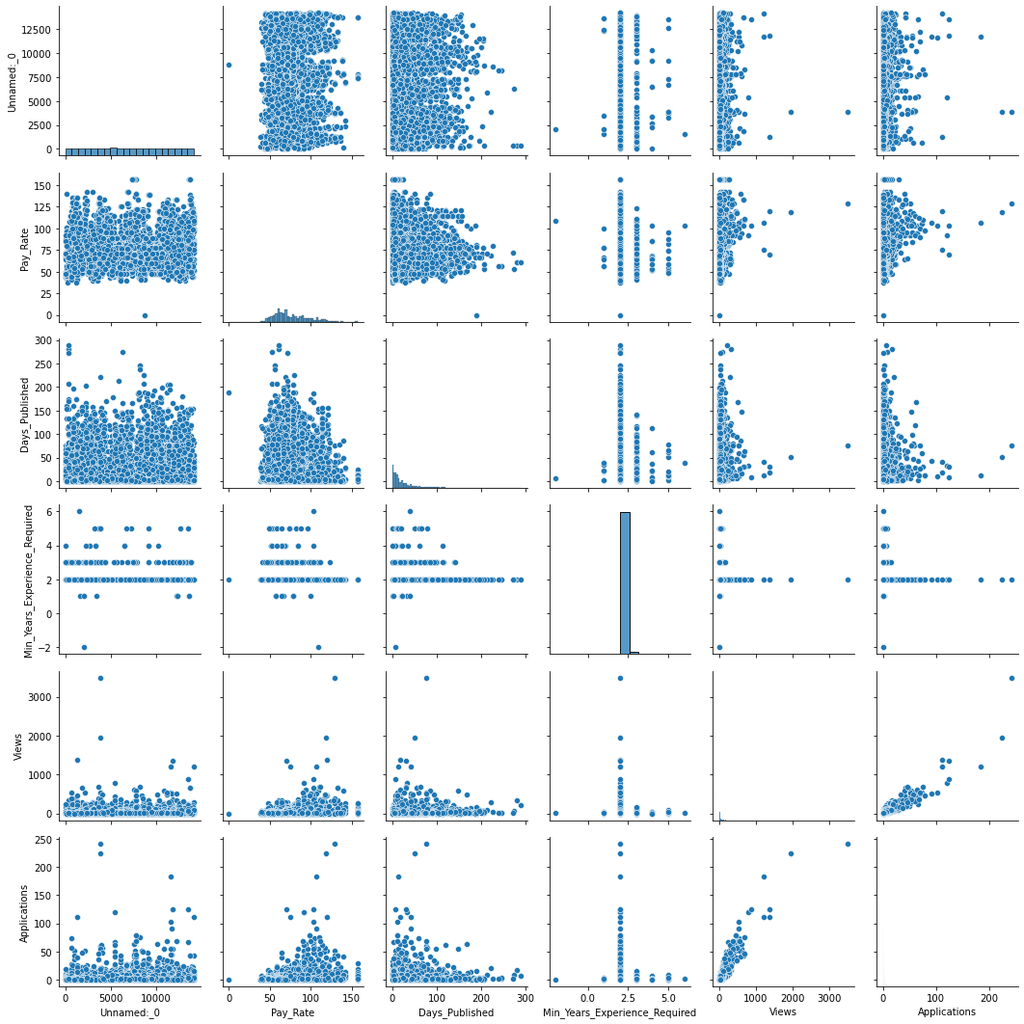

```python
sns.pairplot(df)
```

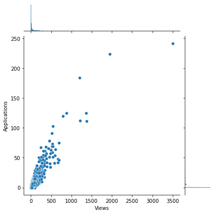

```python
sns.jointplot(data=df, x="Views", y="Applications")
```

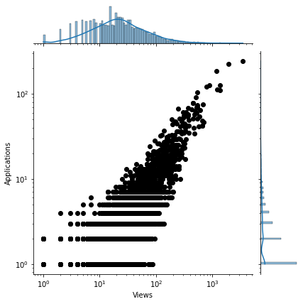

```python
g = sns.JointGrid(
    data=df[(df["Views"] > 0) & (df["Applications"] > 0)], x="Views", y="Applications"
)
g.plot_marginals(sns.histplot, log_scale=True, bins=100, kde=True)
g.plot_joint(plt.scatter, color="black", edgecolor="black")
ax = g.ax_joint
ax.set_xscale("log")
ax.set_yscale("log")
g.ax_marg_x.set_xscale("log")
g.ax_marg_y.set_yscale("log")
```

## 3. Time!

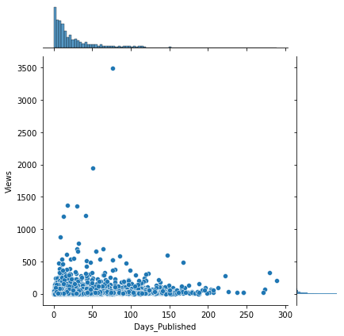

```python
sns.jointplot(data=df, x="Days_Published", y="Views")
```

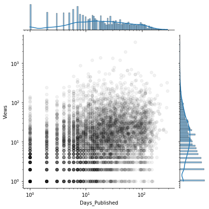

```python
g = sns.JointGrid(
    data=df[(df["Views"] > 0) & (df["Days_Published"] > 0)],
    x="Days_Published",
    y="Views",
)
g.plot_marginals(sns.histplot, log_scale=True, bins=100, kde=True)
g.plot_joint(plt.scatter, color="black", edgecolor="black", alpha=0.05)
ax = g.ax_joint
ax.set_xscale("log")
ax.set_yscale("log")
g.ax_marg_x.set_xscale("log")
g.ax_marg_y.set_yscale("log")
```

```python
x = df.dropna(subset=["Days_Published", "Views"])["Days_Published"]
y = df.dropna(subset=["Days_Published", "Views"])["Views"]
```

```python
r, p = stats.pearsonr(x, y)
r, p
```

```
(0.11235139912563269, 2.2527716905162923e-21)
```

```python
r, p = stats.spearmanr(x, y)
r, p
```

```
(0.3512275230515809, 4.13227930308313e-205)
```

```python
x = np.log(1 + x)
y = np.log(1 + y)
```

```python
r, p = stats.pearsonr(x, y)
r, p
```

```
(0.3617470642161068, 2.329726388593108e-218)
```

```python
r, p = stats.spearmanr(x, y)
r, p
```

```
(0.3512275230515809, 4.13227930308313e-205)
```

## 4. Data Cleaning

1. remove suspicious data
2. remove incomplete data - imputation for further analysis
3. hold out test set
4. data transformation, metrics

```python
df[df["Pay_Rate"] <= 0]
```

|  | Unnamed:_0 | Pay_Rate | Shift_Hours_and_Days | Urbanacity | City | State | Specialization | Last_Published_Date | Days_Published | Min_Years_Experience_Required | Views | Applications |
| --- | --- | --- | --- | --- | --- | --- | --- | --- | --- | --- | --- | --- |
| 4978 | 8795 | 0 | 3x12 | Metropolitan | Memphis | TN | Medical ICU (MICU) | 2021-01-26 | 188.0 | 2.0 | 0 | 0 |

```python
df[df["Min_Years_Experience_Required"] <= 0]
```

|  | Unnamed:_0 | Pay_Rate | Shift_Hours_and_Days | Urbanacity | City | State | Specialization | Last_Published_Date | Days_Published | Min_Years_Experience_Required | Views | Applications |
| --- | --- | --- | --- | --- | --- | --- | --- | --- | --- | --- | --- | --- |
| 1611 | 2015 | 109 | 3x12 | Metropolitan | Bremerton | WA | Medical ICU (MICU) | 2021-01-22 | 6.0 | -2.0 | 2 | 0 |

```python
clean_df = df.drop("Unnamed:_0", axis=1).dropna()
clean_df = clean_df[
    (clean_df[["Pay_Rate", "Min_Years_Experience_Required"]] > 0).all(axis=1)
]
```

```python
(len(df) - len(clean_df)) / len(df)
```

```
0.04705550859397013
```

## 5. Split out test set and do some preprocessing

```python
train_idx, test_idx = train_test_split(
    clean_df.index, test_size=0.2, random_state=8675309
)
```

```python
pca = PCA(n_components=2, random_state=314159)
X = clean_df.loc[train_idx, ["Views", "Applications"]]
X = np.log(1 + X)
pca.fit(X)
pca.explained_variance_ratio_
```

```
array([0.91359251, 0.08640749])
```

```python
X = clean_df[["Views", "Applications"]]
X = np.log(1 + X)
transformed_X = pca.transform(X)
```

```python
clean_df["popularity"] = transformed_X[:, 0]
clean_df["view2app_pc"] = -transformed_X[:, 1]
```

```python
clean_df.loc[train_idx]
```

|  | Pay_Rate | Shift_Hours_and_Days | Urbanacity | City | State | Specialization | Last_Published_Date | Days_Published | Min_Years_Experience_Required | Views | Applications | popularity | view2app_pc |
| --- | --- | --- | --- | --- | --- | --- | --- | --- | --- | --- | --- | --- | --- |
| 4667 | 128 | 3x12 | Metropolitan | El Paso | TX | Medical-Surgical | 2021-02-09 | 1.0 | 2.0 | 38 | 2 | 1.208637 | -0.376317 |
| 6648 | 129 | 3x12 | Metropolitan | Brooklyn | NY | Medical ICU (MICU) | 2021-01-27 | 9.0 | 2.0 | 5 | 1 | -0.602865 | 0.245378 |
| 6047 | 90 | 3x12 | Metropolitan | Burlington | VT | Medical Surgical - Telemetry | 2021-04-05 | 60.0 | 2.0 | 0 | 0 | -2.494750 | 0.579486 |
| 5811 | 64 | 3x12 | Metropolitan | Austin | TX | Operating Room | 2021-04-11 | 19.0 | 2.0 | 3 | 1 | -0.949816 | 0.455204 |
| 2759 | 114 | 3x12 | Metropolitan | Jamaica | NY | Medical-Surgical | 2021-01-27 | 0.0 | 2.0 | 1 | 0 | -1.901633 | 0.220787 |
| ... | ... | ... | ... | ... | ... | ... | ... | ... | ... | ... | ... | ... | ... |
| 6228 | 89 | 3x12 | Metropolitan | New Haven | CT | Medical ICU (MICU) | 2021-03-22 | 1.0 | 2.0 | 7 | 1 | -0.356700 | 0.096504 |
| 5611 | 56 | 3x12 | Metropolitan | Alabaster | AL | Step-Down | 2021-04-14 | 110.0 | 2.0 | 6 | 1 | -0.470961 | 0.165606 |
| 5635 | 99 | 3x12 | Metropolitan | Washington | DC | Step-Down | 2021-01-14 | 6.0 | 2.0 | 0 | 0 | -2.494750 | 0.579486 |
| 2846 | 96 | 3x12 | Metropolitan | Springfield | MA | Emergency Room | 2021-04-21 | 94.0 | 2.0 | 24 | 2 | 0.828125 | -0.146195 |
| 4835 | 96 | 3x12 | Metropolitan | Lake Charles | LA | Telemetry | 2021-04-05 | 15.0 | 2.0 | 194 | 44 | 3.987212 | 1.108051 |

5411 rows × 13 columns

## 6. Simple models

let's start with ordinary least squares...

```python
results = smf.ols(
    formula="popularity ~ Pay_Rate + Min_Years_Experience_Required",
    data=clean_df.loc[train_idx],
).fit()
results.summary()
```

OLS Regression Results

| Dep. Variable: | popularity | R-squared: | 0.085 |
| --- | --- | --- | --- |
| Model: | OLS | Adj. R-squared: | 0.085 |
| Method: | Least Squares | F-statistic: | 251.5 |
| Date: | Sun, 03 Oct 2021 | Prob (F-statistic): | 3.78e-105 |
| Time: | 22:57:10 | Log-Likelihood: | -9655.6 |
| No. Observations: | 5411 | AIC: | 1.932e+04 |
| Df Residuals: | 5408 | BIC: | 1.934e+04 |
| Df Model: | 2 |  |  |
| Covariance Type: | nonrobust |  |  |

|  | coef | std err | t | P>\|t\| | [0.025 | 0.975] |
| --- | --- | --- | --- | --- | --- | --- |
| Intercept | -1.7217 | 0.212 | -8.126 | 0.000 | -2.137 | -1.306 |
| Pay_Rate | 0.0208 | 0.001 | 22.422 | 0.000 | 0.019 | 0.023 |
| Min_Years_Experience_Required | 0.0638 | 0.098 | 0.653 | 0.514 | -0.128 | 0.255 |

| Omnibus: | 114.190 | Durbin-Watson: | 1.993 |
| --- | --- | --- | --- |
| Prob(Omnibus): | 0.000 | Jarque-Bera (JB): | 121.634 |
| Skew: | 0.352 | Prob(JB): | 3.87e-27 |
| Kurtosis: | 3.211 | Cond. No. | 936. |

Notes:  
[1] Standard Errors assume that the covariance matrix of the errors is correctly specified.

```python
results = smf.ols(
    formula="popularity ~ Pay_Rate + Min_Years_Experience_Required + Shift_Hours_and_Days",
    data=clean_df.loc[train_idx],
).fit()
results.summary()
```

OLS Regression Results

| Dep. Variable: | popularity | R-squared: | 0.090 |
| --- | --- | --- | --- |
| Model: | OLS | Adj. R-squared: | 0.089 |
| Method: | Least Squares | F-statistic: | 106.6 |
| Date: | Sun, 03 Oct 2021 | Prob (F-statistic): | 1.23e-107 |
| Time: | 22:57:10 | Log-Likelihood: | -9641.8 |
| No. Observations: | 5411 | AIC: | 1.930e+04 |
| Df Residuals: | 5405 | BIC: | 1.934e+04 |
| Df Model: | 5 |  |  |
| Covariance Type: | nonrobust |  |  |

|  | coef | std err | t | P>\|t\| | [0.025 | 0.975] |
| --- | --- | --- | --- | --- | --- | --- |
| Intercept | -1.6717 | 0.212 | -7.873 | 0.000 | -2.088 | -1.255 |
| Shift_Hours_and_Days[T.4x10] | 0.0426 | 0.093 | 0.460 | 0.646 | -0.139 | 0.224 |
| Shift_Hours_and_Days[T.4x12] | 0.5728 | 0.115 | 4.978 | 0.000 | 0.347 | 0.798 |
| Shift_Hours_and_Days[T.5x8] | 0.1362 | 0.070 | 1.941 | 0.052 | -0.001 | 0.274 |
| Pay_Rate | 0.0205 | 0.001 | 21.906 | 0.000 | 0.019 | 0.022 |
| Min_Years_Experience_Required | 0.0349 | 0.098 | 0.357 | 0.721 | -0.157 | 0.226 |

| Omnibus: | 106.964 | Durbin-Watson: | 1.992 |
| --- | --- | --- | --- |
| Prob(Omnibus): | 0.000 | Jarque-Bera (JB): | 113.285 |
| Skew: | 0.342 | Prob(JB): | 2.51e-25 |
| Kurtosis: | 3.186 | Cond. No. | 940. |

Notes:  
[1] Standard Errors assume that the covariance matrix of the errors is correctly specified.

```python
results = smf.ols(
    formula="popularity ~ Pay_Rate + Min_Years_Experience_Required + Specialization",
    data=clean_df.loc[train_idx],
).fit()
results.summary()
```

OLS Regression Results

| Dep. Variable: | popularity | R-squared: | 0.186 |
| --- | --- | --- | --- |
| Model: | OLS | Adj. R-squared: | 0.178 |
| Method: | Least Squares | F-statistic: | 23.50 |
| Date: | Sun, 03 Oct 2021 | Prob (F-statistic): | 1.79e-197 |
| Time: | 22:57:10 | Log-Likelihood: | -9340.3 |
| No. Observations: | 5411 | AIC: | 1.879e+04 |
| Df Residuals: | 5358 | BIC: | 1.914e+04 |
| Df Model: | 52 |  |  |
| Covariance Type: | nonrobust |  |  |

|  | coef | std err | t | P>\|t\| | [0.025 | 0.975] |
| --- | --- | --- | --- | --- | --- | --- |
| Intercept | -0.6729 | 0.326 | -2.067 | 0.039 | -1.311 | -0.035 |
| Specialization[T.Bone Marrow Transplantation] | -0.8910 | 1.391 | -0.641 | 0.522 | -3.617 | 1.835 |
| Specialization[T.Cardiac Care Unit] | -1.8849 | 0.578 | -3.263 | 0.001 | -3.017 | -0.753 |
| Specialization[T.Cardiac ICU] | -2.0944 | 0.297 | -7.061 | 0.000 | -2.676 | -1.513 |
| Specialization[T.Cardiovascular OR] | -1.6394 | 0.334 | -4.914 | 0.000 | -2.293 | -0.985 |
| Specialization[T.Case Management] | -0.6110 | 0.328 | -1.864 | 0.062 | -1.254 | 0.032 |
| Specialization[T.Cath Lab] | -2.4539 | 0.292 | -8.401 | 0.000 | -3.027 | -1.881 |
| Specialization[T.Chemotherapy] | -2.4325 | 1.000 | -2.432 | 0.015 | -4.393 | -0.472 |
| Specialization[T.Critical Care] | -1.3837 | 0.295 | -4.693 | 0.000 | -1.962 | -0.806 |
| Specialization[T.Dialysis] | -0.8469 | 0.310 | -2.728 | 0.006 | -1.455 | -0.238 |
| Specialization[T.Emergency Room] | -1.0581 | 0.264 | -4.005 | 0.000 | -1.576 | -0.540 |
| Specialization[T.Endoscopy] | -0.7313 | 0.330 | -2.213 | 0.027 | -1.379 | -0.084 |
| Specialization[T.IV Therapy] | -0.5287 | 1.000 | -0.529 | 0.597 | -2.489 | 1.432 |
| Specialization[T.Infusion Therapy] | -0.3998 | 0.548 | -0.730 | 0.465 | -1.474 | 0.674 |
| Specialization[T.Intermediate Care] | -1.9552 | 0.337 | -5.799 | 0.000 | -2.616 | -1.294 |
| Specialization[T.Interventional Radiology] | -1.5214 | 0.340 | -4.469 | 0.000 | -2.189 | -0.854 |
| Specialization[T.Labor & Delivery] | -1.2825 | 0.279 | -4.593 | 0.000 | -1.830 | -0.735 |
| Specialization[T.Long Term Acute Care] | -0.6413 | 0.524 | -1.225 | 0.221 | -1.668 | 0.385 |
| Specialization[T.Long Term Care] | -0.4820 | 0.376 | -1.282 | 0.200 | -1.219 | 0.255 |
| Specialization[T.Medical ICU (MICU)] | -1.9631 | 0.264 | -7.432 | 0.000 | -2.481 | -1.445 |
| Specialization[T.Medical Surgical - Telemetry] | -1.3204 | 0.271 | -4.865 | 0.000 | -1.852 | -0.788 |
| Specialization[T.Medical-Surgical] | -1.0395 | 0.262 | -3.963 | 0.000 | -1.554 | -0.525 |
| Specialization[T.Neonatal ICU (NICU)] | -0.6175 | 0.312 | -1.979 | 0.048 | -1.229 | -0.006 |
| Specialization[T.Neuro ICU] | -2.7734 | 0.305 | -9.085 | 0.000 | -3.372 | -2.175 |
| Specialization[T.Nursery] | -1.1987 | 0.663 | -1.807 | 0.071 | -2.499 | 0.102 |
| Specialization[T.Obstetrics & Gynecology] | -1.4839 | 0.503 | -2.947 | 0.003 | -2.471 | -0.497 |
| Specialization[T.Occupational Health] | -0.6968 | 0.830 | -0.839 | 0.401 | -2.324 | 0.930 |
| Specialization[T.Oncology] | -1.6582 | 0.306 | -5.415 | 0.000 | -2.259 | -1.058 |
| Specialization[T.Operating Room] | -1.7062 | 0.269 | -6.341 | 0.000 | -2.234 | -1.179 |
| Specialization[T.Operating Room - Circulating] | -0.4274 | 0.488 | -0.875 | 0.381 | -1.384 | 0.530 |
| Specialization[T.Operating Room - First Assist] | -2.4390 | 1.391 | -1.754 | 0.080 | -5.166 | 0.287 |
| Specialization[T.Operating Room - Scrub] | -1.7365 | 1.391 | -1.249 | 0.212 | -4.463 | 0.990 |
| Specialization[T.Orthopaedics] | -1.9446 | 0.390 | -4.989 | 0.000 | -2.709 | -1.181 |
| Specialization[T.Outpatient Clinic] | -0.2532 | 0.302 | -0.838 | 0.402 | -0.845 | 0.339 |
| Specialization[T.Pediatric ER] | -1.2415 | 0.577 | -2.150 | 0.032 | -2.374 | -0.109 |
| Specialization[T.Pediatric ICU (PICU)] | -1.7092 | 0.385 | -4.443 | 0.000 | -2.463 | -0.955 |
| Specialization[T.Pediatrics] | 0.0545 | 0.471 | 0.116 | 0.908 | -0.870 | 0.979 |
| Specialization[T.Post-Anesthesia Care Unit (PACU)] | -1.0706 | 0.283 | -3.778 | 0.000 | -1.626 | -0.515 |
| Specialization[T.Postpartum] | -0.9953 | 0.365 | -2.725 | 0.006 | -1.711 | -0.279 |
| Specialization[T.Psychiatry] | -0.4138 | 0.296 | -1.400 | 0.162 | -0.993 | 0.166 |
| Specialization[T.RN First Assistant] | -1.1851 | 1.010 | -1.173 | 0.241 | -3.166 | 0.796 |
| Specialization[T.Radiology] | -2.1534 | 1.000 | -2.153 | 0.031 | -4.114 | -0.193 |
| Specialization[T.Rehabilitation] | -1.2067 | 0.318 | -3.792 | 0.000 | -1.831 | -0.583 |
| Specialization[T.Special Care Unit] | -1.2928 | 1.391 | -0.929 | 0.353 | -4.019 | 1.434 |
| Specialization[T.Step-Down] | -1.6687 | 0.267 | -6.250 | 0.000 | -2.192 | -1.145 |
| Specialization[T.Surgical ICU (SICU)] | -2.4722 | 0.349 | -7.080 | 0.000 | -3.157 | -1.788 |
| Specialization[T.Telemetry] | -1.5890 | 0.266 | -5.973 | 0.000 | -2.111 | -1.067 |
| Specialization[T.Transitional Care Unit] | -0.0574 | 1.391 | -0.041 | 0.967 | -2.784 | 2.669 |
| Specialization[T.Trauma ICU] | -1.8567 | 0.577 | -3.216 | 0.001 | -2.989 | -0.725 |
| Specialization[T.Urology] | -2.1593 | 1.000 | -2.159 | 0.031 | -4.120 | -0.199 |
| Specialization[T.Wound Care] | -1.0157 | 0.548 | -1.854 | 0.064 | -2.090 | 0.058 |
| Pay_Rate | 0.0274 | 0.001 | 28.757 | 0.000 | 0.025 | 0.029 |
| Min_Years_Experience_Required | -0.0058 | 0.094 | -0.061 | 0.951 | -0.191 | 0.179 |

| Omnibus: | 132.113 | Durbin-Watson: | 1.973 |
| --- | --- | --- | --- |
| Prob(Omnibus): | 0.000 | Jarque-Bera (JB): | 147.937 |
| Skew: | 0.354 | Prob(JB): | 7.51e-33 |
| Kurtosis: | 3.394 | Cond. No. | 8.42e+03 |

Notes:  
[1] Standard Errors assume that the covariance matrix of the errors is correctly specified.  
[2] The condition number is large, 8.42e+03. This might indicate that there are  
strong multicollinearity or other numerical problems.

```python
result_df = pd.read_html(results.summary().tables[1].as_html(), header=0, index_col=0)[
    0
]
result_df.sort_values(by="coef", ascending=False)
```

|  | coef | std err | t | P>\|t\| | [0.025 | 0.975] |
| --- | --- | --- | --- | --- | --- | --- |
| Specialization[T.Pediatrics] | 0.0545 | 0.471 | 0.116 | 0.908 | -0.870 | 0.979 |
| Pay_Rate | 0.0274 | 0.001 | 28.757 | 0.000 | 0.025 | 0.029 |
| Min_Years_Experience_Required | -0.0058 | 0.094 | -0.061 | 0.951 | -0.191 | 0.179 |
| Specialization[T.Transitional Care Unit] | -0.0574 | 1.391 | -0.041 | 0.967 | -2.784 | 2.669 |
| Specialization[T.Outpatient Clinic] | -0.2532 | 0.302 | -0.838 | 0.402 | -0.845 | 0.339 |
| Specialization[T.Infusion Therapy] | -0.3998 | 0.548 | -0.730 | 0.465 | -1.474 | 0.674 |
| Specialization[T.Psychiatry] | -0.4138 | 0.296 | -1.400 | 0.162 | -0.993 | 0.166 |
| Specialization[T.Operating Room - Circulating] | -0.4274 | 0.488 | -0.875 | 0.381 | -1.384 | 0.530 |
| Specialization[T.Long Term Care] | -0.4820 | 0.376 | -1.282 | 0.200 | -1.219 | 0.255 |
| Specialization[T.IV Therapy] | -0.5287 | 1.000 | -0.529 | 0.597 | -2.489 | 1.432 |
| Specialization[T.Case Management] | -0.6110 | 0.328 | -1.864 | 0.062 | -1.254 | 0.032 |
| Specialization[T.Neonatal ICU (NICU)] | -0.6175 | 0.312 | -1.979 | 0.048 | -1.229 | -0.006 |
| Specialization[T.Long Term Acute Care] | -0.6413 | 0.524 | -1.225 | 0.221 | -1.668 | 0.385 |
| Intercept | -0.6729 | 0.326 | -2.067 | 0.039 | -1.311 | -0.035 |
| Specialization[T.Occupational Health] | -0.6968 | 0.830 | -0.839 | 0.401 | -2.324 | 0.930 |
| Specialization[T.Endoscopy] | -0.7313 | 0.330 | -2.213 | 0.027 | -1.379 | -0.084 |
| Specialization[T.Dialysis] | -0.8469 | 0.310 | -2.728 | 0.006 | -1.455 | -0.238 |
| Specialization[T.Bone Marrow Transplantation] | -0.8910 | 1.391 | -0.641 | 0.522 | -3.617 | 1.835 |
| Specialization[T.Postpartum] | -0.9953 | 0.365 | -2.725 | 0.006 | -1.711 | -0.279 |
| Specialization[T.Wound Care] | -1.0157 | 0.548 | -1.854 | 0.064 | -2.090 | 0.058 |
| Specialization[T.Medical-Surgical] | -1.0395 | 0.262 | -3.963 | 0.000 | -1.554 | -0.525 |
| Specialization[T.Emergency Room] | -1.0581 | 0.264 | -4.005 | 0.000 | -1.576 | -0.540 |
| Specialization[T.Post-Anesthesia Care Unit (PACU)] | -1.0706 | 0.283 | -3.778 | 0.000 | -1.626 | -0.515 |
| Specialization[T.RN First Assistant] | -1.1851 | 1.010 | -1.173 | 0.241 | -3.166 | 0.796 |
| Specialization[T.Nursery] | -1.1987 | 0.663 | -1.807 | 0.071 | -2.499 | 0.102 |
| Specialization[T.Rehabilitation] | -1.2067 | 0.318 | -3.792 | 0.000 | -1.831 | -0.583 |
| Specialization[T.Pediatric ER] | -1.2415 | 0.577 | -2.150 | 0.032 | -2.374 | -0.109 |
| Specialization[T.Labor & Delivery] | -1.2825 | 0.279 | -4.593 | 0.000 | -1.830 | -0.735 |
| Specialization[T.Special Care Unit] | -1.2928 | 1.391 | -0.929 | 0.353 | -4.019 | 1.434 |
| Specialization[T.Medical Surgical - Telemetry] | -1.3204 | 0.271 | -4.865 | 0.000 | -1.852 | -0.788 |
| Specialization[T.Critical Care] | -1.3837 | 0.295 | -4.693 | 0.000 | -1.962 | -0.806 |
| Specialization[T.Obstetrics & Gynecology] | -1.4839 | 0.503 | -2.947 | 0.003 | -2.471 | -0.497 |
| Specialization[T.Interventional Radiology] | -1.5214 | 0.340 | -4.469 | 0.000 | -2.189 | -0.854 |
| Specialization[T.Telemetry] | -1.5890 | 0.266 | -5.973 | 0.000 | -2.111 | -1.067 |
| Specialization[T.Cardiovascular OR] | -1.6394 | 0.334 | -4.914 | 0.000 | -2.293 | -0.985 |
| Specialization[T.Oncology] | -1.6582 | 0.306 | -5.415 | 0.000 | -2.259 | -1.058 |
| Specialization[T.Step-Down] | -1.6687 | 0.267 | -6.250 | 0.000 | -2.192 | -1.145 |
| Specialization[T.Operating Room] | -1.7062 | 0.269 | -6.341 | 0.000 | -2.234 | -1.179 |
| Specialization[T.Pediatric ICU (PICU)] | -1.7092 | 0.385 | -4.443 | 0.000 | -2.463 | -0.955 |
| Specialization[T.Operating Room - Scrub] | -1.7365 | 1.391 | -1.249 | 0.212 | -4.463 | 0.990 |
| Specialization[T.Trauma ICU] | -1.8567 | 0.577 | -3.216 | 0.001 | -2.989 | -0.725 |
| Specialization[T.Cardiac Care Unit] | -1.8849 | 0.578 | -3.263 | 0.001 | -3.017 | -0.753 |
| Specialization[T.Orthopaedics] | -1.9446 | 0.390 | -4.989 | 0.000 | -2.709 | -1.181 |
| Specialization[T.Intermediate Care] | -1.9552 | 0.337 | -5.799 | 0.000 | -2.616 | -1.294 |
| Specialization[T.Medical ICU (MICU)] | -1.9631 | 0.264 | -7.432 | 0.000 | -2.481 | -1.445 |
| Specialization[T.Cardiac ICU] | -2.0944 | 0.297 | -7.061 | 0.000 | -2.676 | -1.513 |
| Specialization[T.Radiology] | -2.1534 | 1.000 | -2.153 | 0.031 | -4.114 | -0.193 |
| Specialization[T.Urology] | -2.1593 | 1.000 | -2.159 | 0.031 | -4.120 | -0.199 |
| Specialization[T.Chemotherapy] | -2.4325 | 1.000 | -2.432 | 0.015 | -4.393 | -0.472 |
| Specialization[T.Operating Room - First Assist] | -2.4390 | 1.391 | -1.754 | 0.080 | -5.166 | 0.287 |
| Specialization[T.Cath Lab] | -2.4539 | 0.292 | -8.401 | 0.000 | -3.027 | -1.881 |
| Specialization[T.Surgical ICU (SICU)] | -2.4722 | 0.349 | -7.080 | 0.000 | -3.157 | -1.788 |
| Specialization[T.Neuro ICU] | -2.7734 | 0.305 | -9.085 | 0.000 | -3.372 | -2.175 |

```python
results = smf.ols(
    formula="popularity ~ Pay_Rate + Min_Years_Experience_Required + Urbanacity",
    data=clean_df.loc[train_idx],
).fit()
results.summary()
```

OLS Regression Results

| Dep. Variable: | popularity | R-squared: | 0.086 |
| --- | --- | --- | --- |
| Model: | OLS | Adj. R-squared: | 0.085 |
| Method: | Least Squares | F-statistic: | 101.3 |
| Date: | Sun, 03 Oct 2021 | Prob (F-statistic): | 2.00e-102 |
| Time: | 22:57:11 | Log-Likelihood: | -9653.8 |
| No. Observations: | 5411 | AIC: | 1.932e+04 |
| Df Residuals: | 5405 | BIC: | 1.936e+04 |
| Df Model: | 5 |  |  |
| Covariance Type: | nonrobust |  |  |

|  | coef | std err | t | P>\|t\| | [0.025 | 0.975] |
| --- | --- | --- | --- | --- | --- | --- |
| Intercept | -1.7258 | 0.212 | -8.138 | 0.000 | -2.142 | -1.310 |
| Urbanacity[T.Micropolitan] | 0.0056 | 0.085 | 0.066 | 0.947 | -0.161 | 0.172 |
| Urbanacity[T.Rural] | 0.5885 | 0.315 | 1.867 | 0.062 | -0.030 | 1.207 |
| Urbanacity[T.Small Town] | -0.0220 | 0.168 | -0.131 | 0.896 | -0.352 | 0.308 |
| Pay_Rate | 0.0208 | 0.001 | 22.349 | 0.000 | 0.019 | 0.023 |
| Min_Years_Experience_Required | 0.0650 | 0.098 | 0.664 | 0.507 | -0.127 | 0.257 |

| Omnibus: | 113.017 | Durbin-Watson: | 1.994 |
| --- | --- | --- | --- |
| Prob(Omnibus): | 0.000 | Jarque-Bera (JB): | 120.313 |
| Skew: | 0.350 | Prob(JB): | 7.49e-27 |
| Kurtosis: | 3.210 | Cond. No. | 1.28e+03 |

Notes:  
[1] Standard Errors assume that the covariance matrix of the errors is correctly specified.  
[2] The condition number is large, 1.28e+03. This might indicate that there are  
strong multicollinearity or other numerical problems.

```python
results = smf.ols(
    formula="popularity ~ Pay_Rate + Min_Years_Experience_Required + State",
    data=clean_df.loc[train_idx],
).fit()
results.summary()
```

OLS Regression Results

| Dep. Variable: | popularity | R-squared: | 0.148 |
| --- | --- | --- | --- |
| Model: | OLS | Adj. R-squared: | 0.140 |
| Method: | Least Squares | F-statistic: | 19.41 |
| Date: | Sun, 03 Oct 2021 | Prob (F-statistic): | 7.20e-150 |
| Time: | 22:57:11 | Log-Likelihood: | -9462.7 |
| No. Observations: | 5411 | AIC: | 1.902e+04 |
| Df Residuals: | 5362 | BIC: | 1.935e+04 |
| Df Model: | 48 |  |  |
| Covariance Type: | nonrobust |  |  |

|  | coef | std err | t | P>\|t\| | [0.025 | 0.975] |
| --- | --- | --- | --- | --- | --- | --- |
| Intercept | -1.8977 | 0.346 | -5.490 | 0.000 | -2.575 | -1.220 |
| State[T.AL] | 0.1389 | 0.328 | 0.424 | 0.672 | -0.504 | 0.781 |
| State[T.AR] | 0.2212 | 0.305 | 0.726 | 0.468 | -0.376 | 0.819 |
| State[T.AZ] | 0.3995 | 0.304 | 1.315 | 0.189 | -0.196 | 0.995 |
| State[T.CA] | 0.2721 | 0.274 | 0.995 | 0.320 | -0.264 | 0.808 |
| State[T.CO] | 1.3770 | 0.416 | 3.309 | 0.001 | 0.561 | 2.193 |
| State[T.CT] | -0.2883 | 0.329 | -0.877 | 0.381 | -0.933 | 0.356 |
| State[T.DC] | 0.4251 | 0.335 | 1.268 | 0.205 | -0.232 | 1.082 |
| State[T.DE] | 2.2269 | 0.591 | 3.768 | 0.000 | 1.068 | 3.386 |
| State[T.FL] | 0.4191 | 0.270 | 1.554 | 0.120 | -0.110 | 0.948 |
| State[T.GA] | 0.5173 | 0.276 | 1.872 | 0.061 | -0.024 | 1.059 |
| State[T.HI] | 0.9843 | 0.389 | 2.532 | 0.011 | 0.222 | 1.746 |
| State[T.IA] | -0.2580 | 0.399 | -0.647 | 0.518 | -1.040 | 0.524 |
| State[T.ID] | 0.4520 | 0.334 | 1.352 | 0.176 | -0.203 | 1.107 |
| State[T.IL] | 0.4344 | 0.294 | 1.478 | 0.140 | -0.142 | 1.011 |
| State[T.IN] | 1.1518 | 0.345 | 3.338 | 0.001 | 0.475 | 1.828 |
| State[T.KS] | 1.2018 | 0.629 | 1.911 | 0.056 | -0.031 | 2.435 |
| State[T.KY] | 0.5640 | 0.304 | 1.858 | 0.063 | -0.031 | 1.159 |
| State[T.LA] | 1.2496 | 0.308 | 4.051 | 0.000 | 0.645 | 1.854 |
| State[T.MA] | 0.1095 | 0.278 | 0.394 | 0.694 | -0.436 | 0.655 |
| State[T.MD] | 0.6572 | 0.281 | 2.340 | 0.019 | 0.107 | 1.208 |
| State[T.ME] | 0.4505 | 0.303 | 1.485 | 0.138 | -0.144 | 1.045 |
| State[T.MI] | 0.0875 | 0.321 | 0.273 | 0.785 | -0.541 | 0.716 |
| State[T.MN] | 0.6760 | 0.458 | 1.476 | 0.140 | -0.222 | 1.574 |
| State[T.MO] | -0.0080 | 0.299 | -0.027 | 0.979 | -0.594 | 0.578 |
| State[T.MT] | 0.8826 | 0.458 | 1.929 | 0.054 | -0.014 | 1.780 |
| State[T.NC] | 0.2214 | 0.281 | 0.788 | 0.431 | -0.329 | 0.772 |
| State[T.ND] | 0.6203 | 0.395 | 1.571 | 0.116 | -0.154 | 1.394 |
| State[T.NH] | -0.1308 | 0.313 | -0.418 | 0.676 | -0.744 | 0.482 |
| State[T.NJ] | 1.0540 | 0.416 | 2.533 | 0.011 | 0.238 | 1.870 |
| State[T.NM] | 0.7784 | 0.306 | 2.548 | 0.011 | 0.179 | 1.377 |
| State[T.NV] | -0.0374 | 0.319 | -0.117 | 0.907 | -0.663 | 0.588 |
| State[T.NY] | 0.4478 | 0.277 | 1.616 | 0.106 | -0.095 | 0.991 |
| State[T.OH] | 0.3737 | 0.439 | 0.852 | 0.394 | -0.486 | 1.234 |
| State[T.OK] | 0.4707 | 0.338 | 1.393 | 0.164 | -0.192 | 1.133 |
| State[T.OR] | -0.2656 | 0.313 | -0.849 | 0.396 | -0.879 | 0.348 |
| State[T.PA] | 0.1394 | 0.293 | 0.475 | 0.635 | -0.436 | 0.714 |
| State[T.RI] | 0.3830 | 0.747 | 0.513 | 0.608 | -1.082 | 1.848 |
| State[T.SC] | 0.3344 | 0.311 | 1.076 | 0.282 | -0.275 | 0.944 |
| State[T.SD] | -0.5031 | 0.515 | -0.976 | 0.329 | -1.513 | 0.507 |
| State[T.TN] | 0.3346 | 0.293 | 1.143 | 0.253 | -0.239 | 0.908 |
| State[T.TX] | 0.6947 | 0.272 | 2.555 | 0.011 | 0.162 | 1.228 |
| State[T.VA] | 0.2582 | 0.282 | 0.915 | 0.360 | -0.295 | 0.811 |
| State[T.VT] | -1.1128 | 0.292 | -3.816 | 0.000 | -1.684 | -0.541 |
| State[T.WA] | -0.3151 | 0.298 | -1.056 | 0.291 | -0.900 | 0.270 |
| State[T.WI] | -0.1068 | 0.375 | -0.285 | 0.776 | -0.842 | 0.628 |
| State[T.WV] | -0.3975 | 0.405 | -0.982 | 0.326 | -1.191 | 0.396 |
| Pay_Rate | 0.0197 | 0.001 | 20.751 | 0.000 | 0.018 | 0.022 |
| Min_Years_Experience_Required | 0.0248 | 0.097 | 0.256 | 0.798 | -0.165 | 0.215 |

| Omnibus: | 103.567 | Durbin-Watson: | 1.992 |
| --- | --- | --- | --- |
| Prob(Omnibus): | 0.000 | Jarque-Bera (JB): | 112.071 |
| Skew: | 0.319 | Prob(JB): | 4.61e-25 |
| Kurtosis: | 3.302 | Cond. No. | 7.67e+03 |

Notes:  
[1] Standard Errors assume that the covariance matrix of the errors is correctly specified.  
[2] The condition number is large, 7.67e+03. This might indicate that there are  
strong multicollinearity or other numerical problems.

```python
result_df = pd.read_html(results.summary().tables[1].as_html(), header=0, index_col=0)[
    0
]
result_df.sort_values(by="coef", ascending=False)
```

|  | coef | std err | t | P>\|t\| | [0.025 | 0.975] |
| --- | --- | --- | --- | --- | --- | --- |
| State[T.DE] | 2.2269 | 0.591 | 3.768 | 0.000 | 1.068 | 3.386 |
| State[T.CO] | 1.3770 | 0.416 | 3.309 | 0.001 | 0.561 | 2.193 |
| State[T.LA] | 1.2496 | 0.308 | 4.051 | 0.000 | 0.645 | 1.854 |
| State[T.KS] | 1.2018 | 0.629 | 1.911 | 0.056 | -0.031 | 2.435 |
| State[T.IN] | 1.1518 | 0.345 | 3.338 | 0.001 | 0.475 | 1.828 |
| State[T.NJ] | 1.0540 | 0.416 | 2.533 | 0.011 | 0.238 | 1.870 |
| State[T.HI] | 0.9843 | 0.389 | 2.532 | 0.011 | 0.222 | 1.746 |
| State[T.MT] | 0.8826 | 0.458 | 1.929 | 0.054 | -0.014 | 1.780 |
| State[T.NM] | 0.7784 | 0.306 | 2.548 | 0.011 | 0.179 | 1.377 |
| State[T.TX] | 0.6947 | 0.272 | 2.555 | 0.011 | 0.162 | 1.228 |
| State[T.MN] | 0.6760 | 0.458 | 1.476 | 0.140 | -0.222 | 1.574 |
| State[T.MD] | 0.6572 | 0.281 | 2.340 | 0.019 | 0.107 | 1.208 |
| State[T.ND] | 0.6203 | 0.395 | 1.571 | 0.116 | -0.154 | 1.394 |
| State[T.KY] | 0.5640 | 0.304 | 1.858 | 0.063 | -0.031 | 1.159 |
| State[T.GA] | 0.5173 | 0.276 | 1.872 | 0.061 | -0.024 | 1.059 |
| State[T.OK] | 0.4707 | 0.338 | 1.393 | 0.164 | -0.192 | 1.133 |
| State[T.ID] | 0.4520 | 0.334 | 1.352 | 0.176 | -0.203 | 1.107 |
| State[T.ME] | 0.4505 | 0.303 | 1.485 | 0.138 | -0.144 | 1.045 |
| State[T.NY] | 0.4478 | 0.277 | 1.616 | 0.106 | -0.095 | 0.991 |
| State[T.IL] | 0.4344 | 0.294 | 1.478 | 0.140 | -0.142 | 1.011 |
| State[T.DC] | 0.4251 | 0.335 | 1.268 | 0.205 | -0.232 | 1.082 |
| State[T.FL] | 0.4191 | 0.270 | 1.554 | 0.120 | -0.110 | 0.948 |
| State[T.AZ] | 0.3995 | 0.304 | 1.315 | 0.189 | -0.196 | 0.995 |
| State[T.RI] | 0.3830 | 0.747 | 0.513 | 0.608 | -1.082 | 1.848 |
| State[T.OH] | 0.3737 | 0.439 | 0.852 | 0.394 | -0.486 | 1.234 |
| State[T.TN] | 0.3346 | 0.293 | 1.143 | 0.253 | -0.239 | 0.908 |
| State[T.SC] | 0.3344 | 0.311 | 1.076 | 0.282 | -0.275 | 0.944 |
| State[T.CA] | 0.2721 | 0.274 | 0.995 | 0.320 | -0.264 | 0.808 |
| State[T.VA] | 0.2582 | 0.282 | 0.915 | 0.360 | -0.295 | 0.811 |
| State[T.NC] | 0.2214 | 0.281 | 0.788 | 0.431 | -0.329 | 0.772 |
| State[T.AR] | 0.2212 | 0.305 | 0.726 | 0.468 | -0.376 | 0.819 |
| State[T.PA] | 0.1394 | 0.293 | 0.475 | 0.635 | -0.436 | 0.714 |
| State[T.AL] | 0.1389 | 0.328 | 0.424 | 0.672 | -0.504 | 0.781 |
| State[T.MA] | 0.1095 | 0.278 | 0.394 | 0.694 | -0.436 | 0.655 |
| State[T.MI] | 0.0875 | 0.321 | 0.273 | 0.785 | -0.541 | 0.716 |
| Min_Years_Experience_Required | 0.0248 | 0.097 | 0.256 | 0.798 | -0.165 | 0.215 |
| Pay_Rate | 0.0197 | 0.001 | 20.751 | 0.000 | 0.018 | 0.022 |
| State[T.MO] | -0.0080 | 0.299 | -0.027 | 0.979 | -0.594 | 0.578 |
| State[T.NV] | -0.0374 | 0.319 | -0.117 | 0.907 | -0.663 | 0.588 |
| State[T.WI] | -0.1068 | 0.375 | -0.285 | 0.776 | -0.842 | 0.628 |
| State[T.NH] | -0.1308 | 0.313 | -0.418 | 0.676 | -0.744 | 0.482 |
| State[T.IA] | -0.2580 | 0.399 | -0.647 | 0.518 | -1.040 | 0.524 |
| State[T.OR] | -0.2656 | 0.313 | -0.849 | 0.396 | -0.879 | 0.348 |
| State[T.CT] | -0.2883 | 0.329 | -0.877 | 0.381 | -0.933 | 0.356 |
| State[T.WA] | -0.3151 | 0.298 | -1.056 | 0.291 | -0.900 | 0.270 |
| State[T.WV] | -0.3975 | 0.405 | -0.982 | 0.326 | -1.191 | 0.396 |
| State[T.SD] | -0.5031 | 0.515 | -0.976 | 0.329 | -1.513 | 0.507 |
| State[T.VT] | -1.1128 | 0.292 | -3.816 | 0.000 | -1.684 | -0.541 |
| Intercept | -1.8977 | 0.346 | -5.490 | 0.000 | -2.575 | -1.220 |

## 7. XGBoost

```python
feature_cols = [
    "Pay_Rate",
    "Shift_Hours_and_Days",
    "Urbanacity",
    "City",
    "State",
    "Specialization",
    "Min_Years_Experience_Required",
]
label_col = "popularity"
```

```python
encoded_df = clean_df.copy()
lbl = skl.preprocessing.LabelEncoder()
for col in [
    "Shift_Hours_and_Days",
    "Urbanacity",
    "City",
    "State",
    "Specialization",
]:
    encoded_df[col] = lbl.fit_transform(encoded_df[col])
```

```python
dtrain = xgb.DMatrix(
    encoded_df.loc[train_idx, feature_cols],
    label=encoded_df.loc[train_idx, label_col],
    enable_categorical=True,
)
dtest = xgb.DMatrix(
    encoded_df.loc[test_idx, feature_cols],
    label=encoded_df.loc[test_idx, label_col],
    enable_categorical=True,
)
evallist = [(dtrain, "train"), (dtest, "test")]
num_round = 100
param = []
bst = xgb.train(param, dtrain, num_round, evals=evallist, early_stopping_rounds=10)
```

```python
bst.best_iteration
```

```
37
```

```python
bst.best_score
```

```
1.219563
```

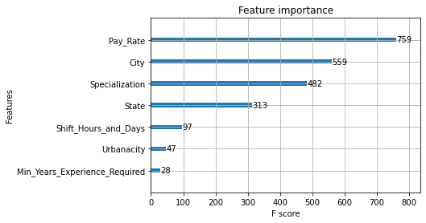

```python
xgb.plot_importance(bst)
```

## 8. Word Vector encoding?

I've never tried this before... lets have some fun

```python
import fasttext
import fasttext.util

fasttext.util.download_model("en", if_exists="ignore")
```

```
'cc.en.300.bin'
```

```python
ft = fasttext.load_model("cc.en.300.bin")
print(ft.get_dimension())
fasttext.util.reduce_model(ft, 100)
print(ft.get_dimension())
```

```
300
100
```

```python
ft.get_word_vector("Pennsylvania")
```

```
array([ 5.67967705e-02, -1.52742602e-02,  3.74847129e-02, -1.16564780e-02,
        2.05002166e-02,  3.29765901e-02,  2.24900506e-02,  1.43502057e-02,
       -2.53527367e-04,  4.15861160e-02,  4.45315987e-02,  2.83213314e-02,
        1.45915188e-02, -1.00772977e-02,  3.32401693e-02, -5.31102791e-02,
        2.25146674e-02,  2.88534388e-02,  2.32879873e-02,  2.42042094e-02,
        1.39877945e-02,  4.75077853e-02, -1.50053976e-02, -2.12171040e-02,
       -7.15364842e-03,  5.34777110e-03,  2.00126618e-02, -9.98555310e-03,
        8.48231744e-03, -1.83664374e-02, -1.25013031e-02, -2.03315597e-02,
       -8.01195018e-03,  1.07608903e-02,  1.50691997e-03, -2.12760419e-02,
        1.41504814e-03,  1.36255007e-02,  1.39806699e-02,  1.81695148e-02,
       -1.73233263e-02,  1.92178573e-04, -7.30806869e-03, -8.66206177e-03,
       -1.09895114e-02, -4.59121875e-02,  1.40140755e-02, -9.24420264e-03,
        2.44539790e-03,  2.11968552e-02, -2.01967242e-03,  1.86452754e-02,
       -5.35122156e-02, -5.01147844e-03, -4.87422645e-02,  2.16166358e-02,
       -8.42877373e-04, -5.63435480e-02,  1.86835732e-05,  4.01585083e-03,
        1.13471765e-02, -1.42581910e-02, -7.77943153e-03, -3.76878344e-02,
        1.75663214e-02,  5.93861565e-03,  2.78144311e-02, -5.61316824e-03,
       -8.93942639e-03, -6.97927456e-03,  1.84952579e-02, -1.74254999e-02,
       -1.84745844e-02,  2.67429762e-02,  1.34152547e-02,  2.46384963e-02,
       -3.94177921e-02,  5.55984229e-02, -3.65834013e-02, -2.22749673e-02,
        1.71778575e-02,  1.07511124e-02, -1.34642562e-02, -1.05247367e-02,
        3.06743905e-02,  3.97868222e-03, -6.75957426e-02,  2.59299278e-02,
       -1.61222962e-03,  2.96982806e-02,  4.33490276e-02, -1.70544349e-02,
        4.45685256e-03, -1.30417421e-02, -9.18661058e-03,  2.03477102e-03,
        2.83925375e-03, -1.77257713e-02, -6.22310385e-04, -1.46164577e-02],
      dtype=float32)
```

```python
us_state_to_abbrev = {
    "Alabama": "AL",
    "Alaska": "AK",
    "Arizona": "AZ",
    "Arkansas": "AR",
    "California": "CA",
    "Colorado": "CO",
    "Connecticut": "CT",
    "Delaware": "DE",
    "Florida": "FL",
    "Georgia": "GA",
    "Hawaii": "HI",
    "Idaho": "ID",
    "Illinois": "IL",
    "Indiana": "IN",
    "Iowa": "IA",
    "Kansas": "KS",
    "Kentucky": "KY",
    "Louisiana": "LA",
    "Maine": "ME",
    "Maryland": "MD",
    "Massachusetts": "MA",
    "Michigan": "MI",
    "Minnesota": "MN",
    "Mississippi": "MS",
    "Missouri": "MO",
    "Montana": "MT",
    "Nebraska": "NE",
    "Nevada": "NV",
    "New Hampshire": "NH",
    "New Jersey": "NJ",
    "New Mexico": "NM",
    "New York": "NY",
    "North Carolina": "NC",
    "North Dakota": "ND",
    "Ohio": "OH",
    "Oklahoma": "OK",
    "Oregon": "OR",
    "Pennsylvania": "PA",
    "Rhode Island": "RI",
    "South Carolina": "SC",
    "South Dakota": "SD",
    "Tennessee": "TN",
    "Texas": "TX",
    "Utah": "UT",
    "Vermont": "VT",
    "Virginia": "VA",
    "Washington": "WA",
    "West Virginia": "WV",
    "Wisconsin": "WI",
    "Wyoming": "WY",
    "District of Columbia": "DC",
    "American Samoa": "AS",
    "Guam": "GU",
    "Northern Mariana Islands": "MP",
    "Puerto Rico": "PR",
    "United States Minor Outlying Islands": "UM",
    "U.S. Virgin Islands": "VI",
}

# invert the dictionary
abbrev_to_us_state = dict(map(reversed, us_state_to_abbrev.items()))
```

```python
wv_df = clean_df.copy()

lbl = skl.preprocessing.LabelEncoder()
for col in [
    "Shift_Hours_and_Days",
    "Urbanacity",
]:
    wv_df[col] = lbl.fit_transform(wv_df[col])

wv_df["State"] = wv_df["State"].map(abbrev_to_us_state)
```

```python
wv_cols = [
    "City",
    "State",
    "Specialization",
]

wv_encodings = [
    wv_df[col]
    .apply(lambda x: pd.Series(ft.get_word_vector(x)))
    .rename(lambda x: f"{col}_{x}", axis=1)
    for col in wv_cols
]
```

```python
wv_df = pd.concat([wv_df] + wv_encodings, axis=1)
```

```python
wv_feature_cols = [col for col in feature_cols if col not in wv_cols] + sum(
    [list(enc.columns) for enc in wv_encodings], []
)
```

```python
dtrain = xgb.DMatrix(
    wv_df.loc[train_idx, wv_feature_cols],
    label=wv_df.loc[train_idx, label_col],
    enable_categorical=True,
)
dtest = xgb.DMatrix(
    wv_df.loc[test_idx, wv_feature_cols],
    label=wv_df.loc[test_idx, label_col],
    enable_categorical=True,
)
evallist = [(dtrain, "train"), (dtest, "test")]
num_round = 100
param = []
wv_bst = xgb.train(param, dtrain, num_round, evals=evallist, early_stopping_rounds=10)
```

```python
wv_bst.best_score
```

```
1.202158
```

```python
bst.best_score
```

```
1.219563
```

# Discussion:

#### How would you productionize this model using a tech stack you’re familiar with? You’re free to assume anything about our codebase and infrastructure, but please list your assumptions.

- This really depends on the use case. Many possibilities
- full sagemaker definitions
- swagger -> docker container -> hosted API
- pip installable package for importing into other scripts and nbs

#### What features would you add to this model to improve it? What else would you do to improve the performance of your model given more time?

- Time analysis
  - look at trajectories, derivative of trajectories, normalize trajectories
  - identify trends earlier

#### What performance metric did you choose to optimize and why is that the best choice?

- RMSE of PCA'd log scaled data

#### Any interesting insights from your data exploration with the data set we provided.

- Pay is unsurprisingly the most informative feature
- City and State are fairly informative as well, though Urbanacity isn't as informative
- Using word vector encodings improves results slightly, may be dimensionality component, not fine-tuned

#### What other predictive models do you think would help our company build a better product for our users and provide the most value to our customers (hospitals)?

- view2app rate
  - based on job description, other factors

#### How could this model be used in the Nomad product suite?

- While posting, show popularity percentile to hospitals
- recommend Pay Rate for given posting